# Economic and Human Consequences of Storms: An Analysis of NOAA Storm Data

# Synopsis

The most dangerous weather event to the population is tornados, followed distantly by heat-related weather. Severe weather has seasonal effects, with tornados doing the most harm to the population in the spring (April), heat-related weather doing the most harm in the summer (July), and flooding in the fall (October.)

# Data Processing

Before performing the analysis, the relevant data was loaded and preprocessed. All code that supports this document is found in the [Github repository](https://github.com/matthewgast/RepData-StormProject) for the project.

1. Environment setup

Several support functions are used in this document, and are contained in the file `script.R`. Therefore, to set up the environment, the support code is loaded. The first thing performed by the code is to load required R packages to support the analysis in the document.

```r
source("script.R")
loadPackages()
```

2. Read data and assess data quality

With the environment set up, data is read by a support function. The support function reads in the data, but performs no processing. When complete, the raw data comprises over 900,000 weather events.

```r
storm.data.raw <- readData()
dim(storm.data.raw)
```

```
## [1] 902297     37
```

Now that the data is in place, look at the column names in the raw data.

```r
names(storm.data.raw)
```

```
##  [1] "STATE__"    "BGN_DATE"   "BGN_TIME"   "TIME_ZONE"  "COUNTY"
##  [6] "COUNTYNAME" "STATE"      "EVTYPE"     "BGN_RANGE"  "BGN_AZI"
## [11] "BGN_LOCATI" "END_DATE"   "END_TIME"   "COUNTY_END" "COUNTYENDN"
## [16] "END_RANGE"  "END_AZI"    "END_LOCATI" "LENGTH"     "WIDTH"
## [21] "F"          "MAG"        "FATALITIES" "INJURIES"   "PROPDMG"
## [26] "PROPDMGEXP" "CROPDMG"    "CROPDMGEXP" "WFO"        "STATEOFFIC"
## [31] "ZONENAMES"  "LATITUDE"   "LONGITUDE"  "LATITUDE_E" "LONGITUDE_"
## [36] "REMARKS"    "REFNUM"
```

With a large amount of data, it is important to assess how much of the data is present. Most of the data fields in the data set are full, with only four fields showing an NAs, none of which matter to the analysis.

```r
countNAs (storm.data.raw)
```

```
##             count
## COUNTYENDN 902297
## F          843563
## LATITUDE       47
## LATITUDE_E     40
```

With the determination of the fields that matter, filter out the data relevant to the analysis. Fields that are final data will be renamed in lower case, with raw data fields needing processing retaining their upper case names. The event type, the number of deaths, and the number of injuries are all in their final form. The date field and economic damages need further processing.

```r
storm.data <- select(storm.data.raw,EVTYPE,BGN_DATE,FATALITIES,INJURIES,PROPDMG,PROPDMGEXP,CROPDMG,CROPDMGEXP)
names(storm.data) <- c("event","BGN_DATE","deaths","injuries","PROPDMG",
          "PROPDMGEXP","CROPDMG","CROPDMGEXP")
```

## Extracting date information

The BGN_DATE field consists of a day and time at which each individual weather event began. For the purpose of seasonal or time series analysis, only the month and year matter, so extract them from the data using the date manipulation fields.

```r
storm.data$month <- as.numeric(format(as.Date(storm.data$BGN_DATE, format = "%m/%d/%Y %H:%M:%S"), "%m"))
storm.data$year <- as.numeric(format(as.Date(storm.data$BGN_DATE, format = "%m/%d/%Y %H:%M:%S"), "%Y"))
```

## Economic damage fields

The basic approach to assessing economic damage is to transform the damage and exponent field into a single number. The damages are expressed as a value plus an exponent, but the value of the exponent field is sometimes a number and sometimes a letter:

```r
levels(storm.data$PROPDMGEXP)
```

```
##  [1] ""  "-" "?" "+" "0" "1" "2" "3" "4" "5" "6" "7" "8" "B" "h" "H" "K"
## [18] "m" "M"
```

```r
levels(storm.data$CROPDMGEXP)
```

```
## [1] ""  "?" "0" "2" "B" "k" "K" "m" "M"
```

The numerical exponent values are straightforward. Letters have well-understood meanings: K for thousand, M for million, and B for billion. However, some exponent fields are blank, have a dash, or question mark. To determine whether these values will throw off the analysis, we can look and see how many times these values occur. Only a total of about 20 events have missing exponents, and account for only a few thousand dollars of damage out of a total of billions.

```r
subset(storm.data,PROPDMGEXP %in% c("-","+","?"))
```

```
##                      event           BGN_DATE deaths injuries PROPDMG
## 188780    BREAKUP FLOODING   5/1/1995 0:00:00      0        0      20
## 189001           HIGH WIND  12/1/1994 0:00:00      0        0      20
## 192262 FLOODING/HEAVY RAIN   3/9/1995 0:00:00      0        0       2
## 198689  THUNDERSTORM WINDS   4/9/1995 0:00:00      0        0       0
## 216755          HIGH WINDS  6/16/1995 0:00:00      0        0      15
## 216802             TORNADO   6/5/1995 0:00:00      0        0      60
## 225254         FLASH FLOOD   5/8/1993 0:00:00      0        0       0
## 227409         FLASH FLOOD   5/8/1993 0:00:00      0        0       0
## 229327           HIGH WIND 12/12/1995 0:00:00      2        0      15
## 232016   THUNDERSTORM WIND   8/5/1994 0:00:00      0        0       0
## 233746                HAIL   9/2/1995 0:00:00      0        0       0
## 233747                HAIL   9/2/1995 0:00:00      0        0       0
## 233748                HAIL   9/2/1995 0:00:00      0        0       0
## 247617  THUNDERSTORM WINDS  7/13/1995 0:00:00      0        0       0
##        PROPDMGEXP CROPDMG CROPDMGEXP month year
## 188780          +       0                5 1995
## 189001          +       0               12 1994
## 192262          +       0                3 1995
## 198689          ?       0                4 1995
## 216755          +       0                6 1995
## 216802          +       0                6 1995
## 225254          ?       0                5 1993
## 227409          ?       0                5 1993
## 229327          -       0               12 1995
## 232016          ?       0                8 1994
## 233746          ?       0                9 1995
## 233747          ?       0                9 1995
## 233748          ?       0                9 1995
## 247617          ?       0                7 1995
```

```r
subset(storm.data,CROPDMGEXP %in% c("-","+","?"))
```

```
##                     event          BGN_DATE deaths injuries PROPDMG
## 192467  FLASH FLOOD WINDS  3/9/1995 0:00:00      0        0    0.41
## 197066 THUNDERSTORM WINDS 2/12/1993 0:00:00      0        0    0.50
## 197331 THUNDERSTORM WINDS 2/12/1993 0:00:00      0        0    0.50
## 220300 THUNDERSTORM WINDS 7/31/1995 0:00:00      0        0    0.00
## 220877  FLOOD/FLASH FLOOD 2/16/1995 0:00:00      0        0  400.00
## 232901  FLOOD/FLASH FLOOD 8/26/1995 0:00:00      0        0    0.50
## 242953 THUNDERSTORM WINDS 4/17/1995 0:00:00      0        0   80.00
##        PROPDMGEXP CROPDMG CROPDMGEXP month year
## 192467                  0          ?     3 1995
## 197066          K       0          ?     2 1993
## 197331          K       0          ?     2 1993
## 220300                  0          ?     7 1995
## 220877          K       0          ?     2 1995
## 232901          M       0          ?     8 1995
## 242953          K       0          ?     4 1995
```

With the help of a support function to translate an exponent character into the power of 10 on a muliplier, we can convert the exponents into numeric values. By comparing the levels of the fields in the raw data (PROPDMGEXP and CROPDMGEXP) to their translated counterparts (propExponent and cropExponent), it is possible to get an idea of the magnitude of the impact of severe weather. Property damage events with billions of dollars in damage are significantly more common, and more events damage property than crops. By comparison, the original raw data fields were translated correctly. For example, in property damage, there are 11,330 events in the “M”illon range, 7 events in the “m”illion range, and 4 events that use an exponent of 10^6, or, million. When translated, there are 11,341 events that have the exponent of 10^6, which matches identically.

```r
propExponent <- mapply(exponentTranslator,storm.data$PROPDMGEXP)
cropExponent <- mapply(exponentTranslator,storm.data$CROPDMGEXP)
table(storm.data$PROPDMGEXP)
```

```
##
##             -      ?      +      0      1      2      3      4      5
## 465934      1      8      5    216     25     13      4      4     28
##      6      7      8      B      h      H      K      m      M
##      4      5      1     40      1      6 424665      7  11330
```

```r
table(propExponent)
```

```
## propExponent
##      0      1      2      3      4      5      6      7      8      9
##    216 465973     20 424669      4     28  11341      5      1     40
```

```r
table (storm.data$CROPDMGEXP)
```

```
##
##             ?      0      2      B      k      K      m      M
## 618413      7     19      1      9     21 281832      1   1994
```

```r
table(cropExponent)
```

```
## cropExponent
##      0      1      2      3      6      9
##     19 618420      1 281853   1995      9
```

With exponents now available in numeric form, translate the damage value and exponents into total damage fields.

```r
storm.data <- cbind(storm.data,propExponent,cropExponent)
storm.data <- mutate(storm.data,propertyDamage=PROPDMG*10^propExponent,
                     cropDamage=CROPDMG*10^cropExponent)
```

## Event simplification

The coding of events in the storm data is somewhat haphazard. There are 985 event types, but a casual inspection reveals many inconsistencies. For example, a search through the event types determines that there are over 100,000 thunderstorm events, and those events have 82 different text descriptions.

```r
length(unique(storm.data$event))
```

```
## [1] 985
```

```r
name.contains.tstorm <- grepl("THUNDERSTORM",storm.data$event,ignore.case=TRUE)
sum(name.contains.tstorm)
```

```
## [1] 109572
```

```r
length(unique(storm.data[name.contains.tstorm,]$event))
```

```
## [1] 82
```

To shrink the event types to a manageable size, we begin by converting all text to upper case to avoid case mismatches. The function `topEvents` prints out the top 10 events and the number of times they appear in the database. Three of the top 10 events have essentially identical descriptors: “TSTM WIND”, “THUNDERSTORM WIND”, and “THUNDERSTORM WINDS”.

```r
storm.data$event <- toupper(storm.data$event)
topEvents(storm.data,10)
```

```
##
##               HAIL          TSTM WIND  THUNDERSTORM WIND
##             288661             219942              82564
##            TORNADO        FLASH FLOOD              FLOOD
##              60652              54277              25327
## THUNDERSTORM WINDS          HIGH WIND          LIGHTNING
##              20843              20214              15754
##         HEAVY SNOW
##              15708
```

```r
source("simplifyEvents.R")
storm.data <- simplifyEvents(storm.data)
topEvents(storm.data,10)
```

```
##
## THUNDERSTORM WIND              HAIL           TORNADO       FLASH FLOOD
##            324728            288829             60684             55039
##             FLOOD              WIND            WINTER              SNOW
##             30138             26013             19693             16610
##         LIGHTNING              RAIN
##             15755             11854
```

```r
length(unique(storm.data$event))
```

```
## [1] 419
```

The final step in processing event types is to reformat event types as mixed-case names with the help of a function that rewrites even types to have an initial capital letter in each word.

```r
storm.data$event <- sapply(storm.data$event, initialCap)
```

## Final data processing

The final steps in data processing are to drop extraneous columns of raw data, retaining only the even type, casualty counts, damage information, and the extracted month and year. Finally, the column order is rewritten so that related columns are next to each other to improve readability.

```r
storm.data <- select(storm.data,event,deaths,injuries,propertyDamage,cropDamage,month,year)
storm.data <- mutate(storm.data,
            totalDamage=propertyDamage+cropDamage,
            casualties=deaths+injuries)
storm.data = storm.data %>% select(event,year,month,propertyDamage,cropDamage,totalDamage,deaths,injuries,casualties)
```

The final bit of data processing is to create a second array that holds data on the effects of each event type. When aggregating events, we only wish to aggregate economic damage and casualty data, and it does not make sense to aggregate month and year numbers.

```r
effect.by.event <- aggregate (cbind(propertyDamage,
                        cropDamage,
                                    totalDamage,
                    deaths,
                    injuries,
                    casualties) ~ event,
                   data=storm.data,
                   FUN=sum)
```

# Research Question 1: Human Effect of Events

This section of the paper answers the question: *Across the United States, which types of events (as indicated in the EVTYPE variable) are most harmful with respect to population health?*

By far, the most dangerous weather events are tornados, with nearly ten times the casualties of the next event type, as readily seen in the first plot in the panel below. Fortunately, most casualties inflicted on the population from severe weather is due to injury, and not death.

By far the leading cause of death is tornados, followed by heat, flash floods, lightning, and thunderstorm-related winds. The leading causes of injuries are tornados, thunderstorm-related winds, heat, and flooding. Flash floods tend to kill, while normal floods injure. Depending on the propensity of an area to suffer from floods versus flash floods may result in different emerency planning.

Different weather events have different seasonal patterns, as shown by the second graph in the panel below. Tornado activity is most prominent in the spring. Heat activity and flash floods occur prominently in the summer, and floods happen mostly in the fall. Depending on the type of severe weather expected, emergency management agencies may need to be ready at different times of year.

To obtain the graphs in the panel below, the raw data was summarized by event type. This paper combines deaths and injuries into a single casualty measurement, and produced graphs containing only the top 10 casualty-causing events. Plotting both deaths and injuries on the same scale was facilitated by using the `melt` function to reformat the data to be more compatible with plotting functions. Seasonal graphs were obtained by summarizing results by month over the course of the entire data set.

```r
casualties.by.event <- head(select(arrange(effect.by.event,desc(casualties)),event,deaths,injuries),n=10)
top10.casualty.event <- casualties.by.event$event
long.format.casualties <- melt(casualties.by.event)
```

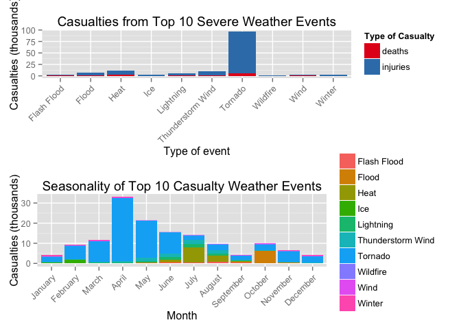

```r
casualties.g <- ggplot(long.format.casualties, aes(x = event,
                   y = value,
                   fill=variable)) +
     geom_bar(stat='identity') +
     xlab("Type of event") +
     theme(axis.text.x = element_text(angle=45, hjust=1)) +
     ylab("Casualties (thousands)") +
     scale_y_continuous(labels=thousands) +
     ggtitle("Casualties from Top 10 Severe Weather Events") +
     scale_fill_brewer(palette="Set1",label=c("deaths","injuries")
                      ) +
     labs(fill = "Type of Casualty")

monthly.top10.casualties <- filter(storm.data,event %in% top10.casualty.event)
monthly.casualties <- aggregate (. ~ event+month,data=monthly.top10.casualties,FUN=sum)
casualty.seasons.g <- ggplot(monthly.casualties,aes(
                x=reorder(month.name[month],month),
                y=casualties,
                fill=event)
                 ) +
       geom_bar(stat='identity') +
       theme(legend.title=element_blank(),
             axis.text.x=element_text(angle=45, hjust=1)
             ) +
       xlab("Month") +
       ylab("Casualties (thousands)") +
       scale_y_continuous(labels=thousands) +
       ggtitle("Seasonality of Top 10 Casualty Weather Events")

grid.arrange(casualties.g,casualty.seasons.g,ncol=1)
```

# Research Question 2: Economic Consequences of Weather

*Across the United States, which types of events have the greatest economic consequences?*

Economic consequences are divided into damage to property and damage to crops. As before, total damages are plotted in the first in the first panel. Damage is dominated by property damage, which is far greater than total crop damage. The panel plots only the top ten event types that cause economic damage. All but one of the ten events caused more damage to property than crops.

The leading cause of property damage is flooding, followed by hurricanes and storm surges (often related), and tornados. Crop damage is due mainly to droughts and floods, with somewhat smaller contributions from hurricanes, ice, and hail.

As with casualties, economic damage has seasonal flows. Spring property damage in April and May is caused by tornados, while fall property damage in August through October is caused by the peak of hurricane and storm surge. Crop damage is caused mainly during the summer, which is not surprising given the agricultural growing season. Both droughts and floods have similar peak seasons in June through September.

To obtain the graphs in the panel below, the raw data was summarized by event type. This paper combines both property and crop damage into a total damage measurement, and produced graphs containing only the top 10 economic damage-causing events. Plotting both types of economic damage on the same scale was facilitated by using the `melt` function to reformat the data to be more compatible with plotting functions. Seasonal graphs were obtained by summarizing results by month over the course of the entire data set.

```r
damage.by.event <- head(select(arrange(effect.by.event,desc(totalDamage)),event,cropDamage,propertyDamage),n=10)
long.format.damage <- melt(damage.by.event)
```

[figure not shown]

```r
damage.g <- ggplot(long.format.damage, aes(x = event,
                   y = value,
                   fill=variable)) +
     geom_bar(stat='identity') +
     xlab("Type of event") +
     theme(axis.text.x = element_text(angle=45, hjust=1)) +
     ylab("US$ Damage (billions)") +
     scale_y_continuous(labels=billions) +
     ggtitle("Economic Damage from Severe Weather") +
     scale_fill_brewer(palette="Set1",label=c("Crop","Property")
                      ) +
     labs(fill = "Damage Type")

propdmg.by.event <- head(select(arrange(effect.by.event,desc(propertyDamage)),event,propertyDamage),n=10)
top10.propdmg.event <- propdmg.by.event$event
monthly.top10.propdmg <- filter(storm.data,event %in% top10.propdmg.event)
monthly.propdmg <- aggregate (. ~ event+month,data=monthly.top10.propdmg,FUN=sum)
property.seasons.g <- ggplot(monthly.propdmg,aes(
                x=reorder(month.name[month],month),
                y=propertyDamage,
                fill=event)
                ) +
       geom_bar(stat='identity') +
       theme(legend.title=element_blank(),
         axis.text.x=element_text(angle=45, hjust=1)) +
       xlab("Month") +
       ylab("Property Damage (billion USD)") +
       scale_y_continuous(labels=billions) +
       ggtitle("Seasonality of Top 10 Property Damage Weather Events")

cropdmg.by.event <- head(select(arrange(effect.by.event,desc(cropDamage)),event,cropDamage),n=10)
top10.cropdmg.event <- cropdmg.by.event$event
monthly.top10.cropdmg <- filter(storm.data,event %in% top10.cropdmg.event)
monthly.cropdmg <- aggregate (. ~ event+month,data=monthly.top10.cropdmg,FUN=sum)
crop.seasons.g <- ggplot(monthly.cropdmg,aes(
                x=reorder(month.name[month],month),
                y=cropDamage,
                fill=event)
                ) +
       geom_bar(stat='identity') +
       theme(legend.title=element_blank(),
         axis.text.x=element_text(angle=45, hjust=1)) +
       xlab("Month") +
       ylab("Crop Damage (billion USD)") +
       scale_y_continuous(labels=billions) +
       ggtitle("Seasonality of Top 10 Crop Damage Weather Events")

grid.arrange(damage.g,property.seasons.g,crop.seasons.g,ncol=1)
```

# Appendix: Simplifying weather types